# Lab 12: Статистические тесты

**Сегодня диктант на степике!** Курс: https://stepik.org/course/48420/syllabus Приглашение для тех, кто еще не присоединился: https://stepik.org/invitation/03f310a9f966907113a0975e446972f9b1be1e55/

### Формулирование и проверка гипотез

Гипотезы:

- **нулевая** ($H_0$), которая проверяется на правильность (отвергает начиличие эффекта)
- **альтернативная** ($H_A$), отвергающая нулевую

После того как гипотезы сформулированы, необходимо выбрать **уровень значимости** – ($\alpha$ – допустимая вероятность *ошибочно* отклонить *истинную* $H_0$).

[Различие нулевой и альтернативной гипотез с примерами](https://www.thoughtco.com/null-hypothesis-vs-alternative-hypothesis-3126413)

*Дополнительно*:

- [про независимые и зависимые переменные](https://www.thoughtco.com/i-ndpendent-and-dependent-variables-differences-606115)
- [про уровень значимости](http://www.machinelearning.ru/wiki/index.php?title=%D0%A3%D1%80%D0%BE%D0%B2%D0%B5%D0%BD%D1%8C_%D0%B7%D0%BD%D0%B0%D1%87%D0%B8%D0%BC%D0%BE%D1%81%D1%82%D0%B8)

### P-value

**P-value** – вероятность получить такой же результат, как есть в данных, или еще больший, **при условии, что нуль-гипотеза верна**.

Как интерпретировать и как **не** интерпретировать [p-значение](http://blog.minitab.com/blog/adventures-in-statistics-2/how-to-correctly-interpret-p-values)

Не забываем загружать пакеты, которые нужны для работы

```r
library(ggplot2)
library(dplyr)
library(readr)
```

### По мотивам лекции

Загрузим данные про оценки по математике и социологии для экономистов и социологов (+ перцентиль в соответствующем рейтинге, нормированная оценка, специальность и запись на майнор)

```r
rates = read_csv("~/shared/minor2_2018/1-intro/lab12-stat_tests/rates.csv")
```

Посмотрим на разницу в оценках по графикам. Что можно сказать?

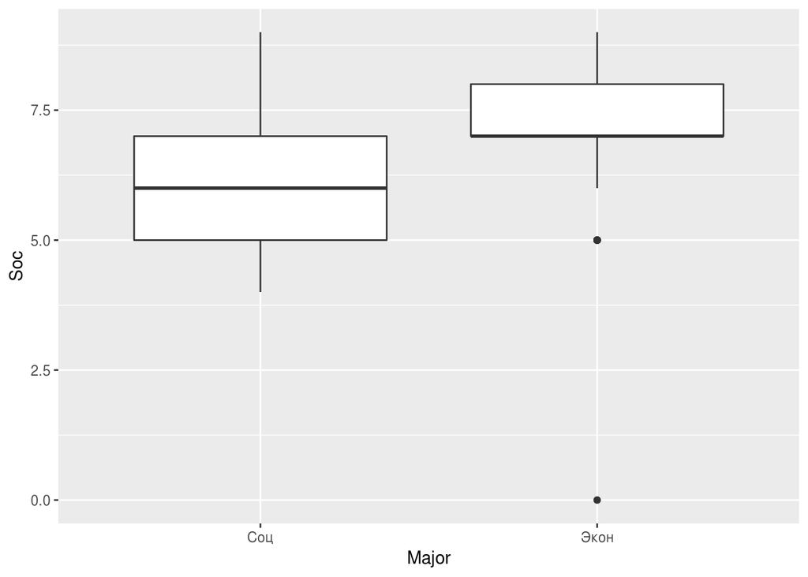

```r
ggplot(rates) +
  geom_boxplot(aes(x=Major, y=Soc))
```

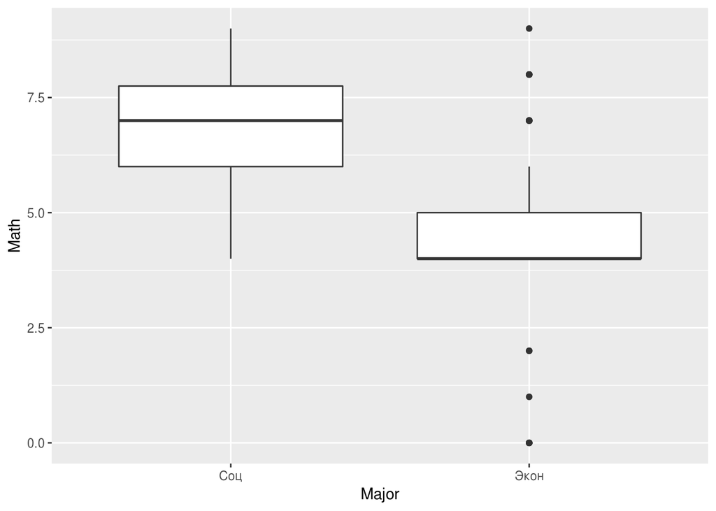

```r
ggplot(rates) +
  geom_boxplot(aes(x=Major, y=Math))
```

Вычислим разность средних оценок явным образом (для отличия от лекции – по математике)

```r
All_means = rates %>%
  group_by(Major) %>%
  summarize(
    Math.observed = mean(Math),
    Soc.observed = mean(Soc),
    s = sum(abs)
  )

All_means
```

```
## # A tibble: 2 x 4
##   Major Math.observed Soc.observed     s
##   <chr>         <dbl>        <dbl> <dbl>
## 1 Соц            6.76         6.22  69.7
## 2 Экон           4.64         6.99 108
```

```r
diff.observed = All_means$Math.observed[1] - All_means$Math.observed[2]
diff.observed
```

```
## [1] 2.119481
```

Можем ли мы сказать велика ли разница?

### Гипотеза

Попробуем понять, есть какая-то закономерность приводящая к разнице оценок, или это всего лишь случайность.

1. Сформулируем наш вопрос на языке статистики (то есть определим $H_0$ и $H_A$)
   - Например: $H_0:$ Средняя оценка по математике одинаковая для экономистов и социологов; $H_A:$ Средние оценки различаются.
2. Выберем уровень значимости ($\alpha$ – допустимая вероятность **ошибочно** отклонить **истинную** $H_0$)
3. Определим подходящую к нашим данным статистику и вычислим ее.
4. Проверим, достаточно ли у нас оснований отклонить нулевую гипотезу (для выбранного значения $\alpha$)
5. Сформулируем наши выводы на “человеческом” языке.

## t-критерий

- если мы хотим сравнить средние значения в двух группах

Предположения t-критерия:

- нормально распределенные данные в выборке (что это значит?)
- данные независимые, одинаково распределенные
- для некоторых вариантов критерия – еще и предположения о равенстве дисперсий

Сравним положение в рейтинге у записавшихся и не записавшихся на DS майнор.

**При тестировании мы предполагаем, что нуль-гипотеза истинна.**

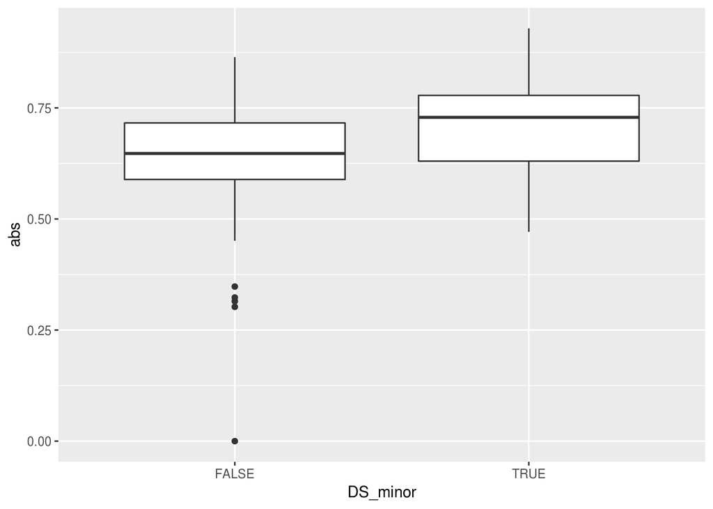

```r
ggplot(data = rates) +
  geom_boxplot(aes(x = DS_minor, y = abs))
```

```r
# формула выглядит знакомой?
t.test(abs ~ DS_minor, data = rates)
```

```
##
##  Welch Two Sample t-test
##
## data:  abs by DS_minor
## t = -4.8441, df = 185.56, p-value = 2.674e-06
## alternative hypothesis: true difference in means is not equal to 0
## 95 percent confidence interval:
##  -0.09112714 -0.03838270
## sample estimates:
## mean in group FALSE  mean in group TRUE
##           0.6455391           0.7102940
```

- Какой вывод можно сделать?

## С какими параметрами связана цена жилья

Переходим к данным с ценами на жилье. Сначала загрузим данные [House Pricing](https://www.kaggle.com/c/house-prices-advanced-regression-techniques/data)

```r
housing = read_csv("~/shared/minor2_2018/1-intro/data/housing.csv")
```

Описание остальных переменных можно найти на Kaggle

```r
housing = housing %>%
  select(SalePrice, OverallCond, Neighborhood, Utilities,
         LotArea, YearBuilt, CentralAir, GarageFinish,
         GarageCars, PoolQC, HeatingQC)
```

Посмотрим на данные

```r
str(housing, max.level = 1)
```

```
## Classes 'tbl_df', 'tbl' and 'data.frame':    1460 obs. of  11 variables:
##  $ SalePrice   : int  208500 181500 223500 140000 250000 143000 307000 200000 129900 118000 ...
##  $ OverallCond : int  5 8 5 5 5 5 5 6 5 6 ...
##  $ Neighborhood: chr  "CollgCr" "Veenker" "CollgCr" "Crawfor" ...
##  $ Utilities   : chr  "AllPub" "AllPub" "AllPub" "AllPub" ...
##  $ LotArea     : int  8450 9600 11250 9550 14260 14115 10084 10382 6120 7420 ...
##  $ YearBuilt   : int  2003 1976 2001 1915 2000 1993 2004 1973 1931 1939 ...
##  $ CentralAir  : chr  "Y" "Y" "Y" "Y" ...
##  $ GarageFinish: chr  "RFn" "RFn" "RFn" "Unf" ...
##  $ GarageCars  : int  2 2 2 3 3 2 2 2 2 1 ...
##  $ PoolQC      : chr  NA NA NA NA ...
##  $ HeatingQC   : chr  "Ex" "Ex" "Ex" "Gd" ...
##  - attr(*, "spec")=List of 2
##   ..- attr(*, "class")= chr "col_spec"
```

В частности, переменные Utilities (удобства) и PoolQC (бассейн) нам не очень интересны – практически везде есть все удобства и почти нигде нет бассейна

Для более удобной работы выразим цену в тысячах

```r
housing = housing %>%
  mutate(SalePrice = SalePrice/1000)
```

А теперь начнем исследовать, какие же параметры взаимосвязаны с ценой. Сначала очевидный параметр – площадь. Создадим новую переменную, отражающую дома с площадью меньше и больше 10000

```r
housing = housing %>%
  mutate(area10000 = ifelse(LotArea > 10000, "More 10000", "Less 10000"))
```

А теперь сравниваем средние

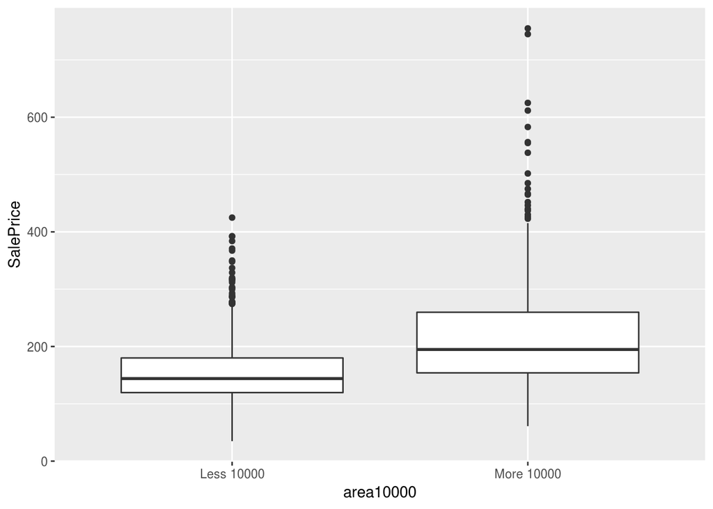

```r
ggplot(housing) + geom_boxplot(aes(x = area10000, y = SalePrice))
```

```r
t.test(SalePrice ~ area10000, data = housing)
```

```
##
##  Welch Two Sample t-test
##
## data:  SalePrice by area10000
## t = -15.121, df = 923.31, p-value < 2.2e-16
## alternative hypothesis: true difference in means is not equal to 0
## 95 percent confidence interval:
##  -71.31293 -54.92850
## sample estimates:
## mean in group Less 10000 mean in group More 10000
##                 154.2030                 217.3237
```

## Ваша очередь

Сравните цену на жилье по следующим параметрам

- Хорошее vs плохое состояние жилья. Хорошим состоянием считаем параметр `OverallCond` больше 5 (т.е. 10: Very Excellent, 9: Excellent, 8: Very Good, 7: Good, 6: Above Average – см. описание)
- Построено раньше 1970 vs позже 1970 (параметр `YearBuilt`)
- Построено с 1960 по 1970 vs с 1970 по 1980 (параметр `YearBuilt`)

```r
#немного поможем с преобразованиями
housing2 = housing %>%
  filter(YearBuilt > 1960 & YearBuilt <= 1980) %>%
  mutate(year1970 = ifelse(YearBuilt > 1970, ">1970", "<1970"))
```

- Есть центральная вентиляция vs нет (`CentralAir`)
- Есть гараж vs нет. Смотрим по переменной `GarageFinish`: если ее значение NA, то гаража нет. Проверить можно с помощью `is.na(housing$GarageFinish)`
- Для тех домов, где есть гараж, по его размеру: помещается 2 машины и больше vs меньше двух машин (`GarageCars`)
- Район OldTown vs Edwards (`Neighborhood`)
- … Ваши варианты вопросов

## Хи-квадрат

- А если нам нужно сравнить не две группы по значению метрической переменной? А выяснить взаимосвязь между двумя категориальными?

Есть ли взаимсовязь между выбором майнора и специальностью? Другими словами, влияет ли специальность на выбор майнора?

```r
table(rates$Major, rates$DS_minor)
```

```
##
##        FALSE TRUE
##   Соц     59   35
##   Экон   122   51
```

Формальные результаты теста

```r
ch = chisq.test(rates$Major, rates$DS_minor)
ch
```

```
##
##  Pearson's Chi-squared test with Yates' continuity correction
##
## data:  rates$Major and rates$DS_minor
## X-squared = 1.3409, df = 1, p-value = 0.2469
```

- Выводы?

Наблюдаемые и ожидаемые значения

```r
ch$observed
```

```
##            rates$DS_minor
## rates$Major FALSE TRUE
##        Соц     59   35
##        Экон   122   51
```

```r
ch$expected
```

```
##            rates$DS_minor
## rates$Major     FALSE     TRUE
##        Соц   63.72285 30.27715
##        Экон 117.27715 55.72285
```

Таблица Пирсоновских остатков

```r
ch$residuals
```

```
##            rates$DS_minor
## rates$Major      FALSE       TRUE
##        Соц  -0.5916382  0.8583142
##        Экон  0.4361111 -0.6326845
```

Отклонения от ожидаемого

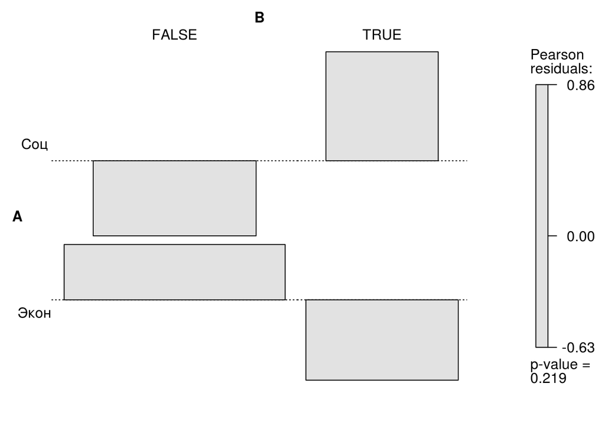

```r
library(vcd)
assoc(table(rates$Major, rates$DS_minor), gp=shading_max,
      rot_labels = c(0, 0, 0, 0),
      rot_varnames = c(0, 0, 0, 0))
```

Или же все вместе на одном графике (полезно, если таблицы больше, чем на 2 на 2)

```r
df_resid = as.data.frame(ch$residuals)
df_resid
```

```
##   rates.Major rates.DS_minor       Freq
## 1         Соц          FALSE -0.5916382
## 2        Экон          FALSE  0.4361111
## 3         Соц           TRUE  0.8583142
## 4        Экон           TRUE -0.6326845
```

```r
df_count = as.data.frame(ch$observed)
df_count
```

```
##   rates.Major rates.DS_minor Freq
## 1         Соц          FALSE   59
## 2        Экон          FALSE  122
## 3         Соц           TRUE   35
## 4        Экон           TRUE   51
```

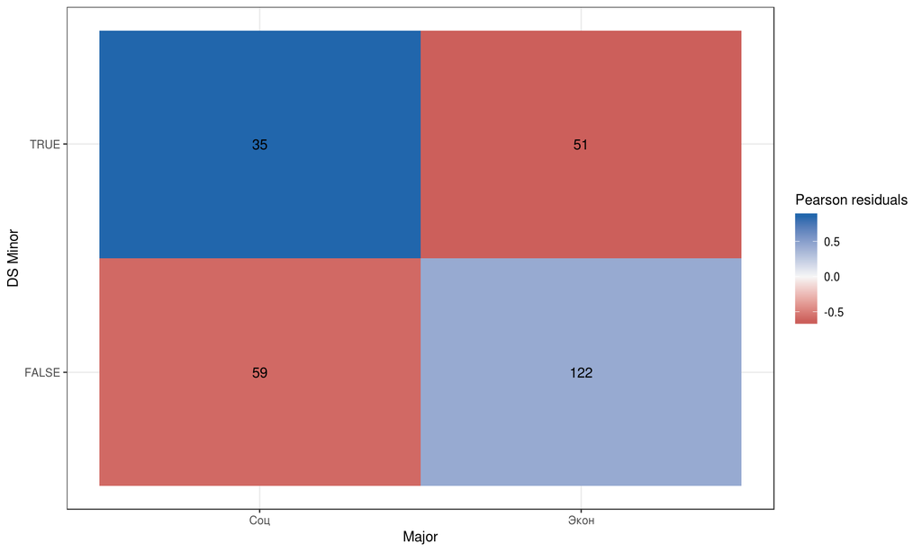

```r
ggplot() +
  geom_raster(data = df_resid, aes(x = rates.Major, y = rates.DS_minor, fill = Freq), hjust = 0.5, vjust = 0.5) +
  scale_fill_gradient2("Pearson residuals", low = "#b2182b", mid = "#f7f7f7", high = "#2166ac", midpoint = 0) +
  geom_text(data = df_count, aes(x = rates.Major, y = rates.DS_minor, label = Freq)) +
  xlab("Major") +
  ylab("DS Minor") +
  theme_bw()
```

Итак, вернемся к домохозяйствам. Данные снова[House Pricing](https://www.kaggle.com/c/house-prices-advanced-regression-techniques/data)

Посмотрим на взаимосвязь качества отопления и годом постройки (ранее 1950). В данных всего один дом с очень плохим отоплением, поэтому уберем его перед сравнением

```r
#housing = read_csv("~/shared/minor2_2018/1-intro/data/housing.csv")
#housing = housing %>% select(SalePrice, OverallCond, Neighborhood, Utilities, LotArea, YearBuilt, CentralAir, GarageFinish, GarageCars, PoolQC, HeatingQC)

housing2 = housing %>%
  mutate(year1950 = ifelse(YearBuilt > 1950, ">1950", "<1950")) %>%
  filter(HeatingQC != "Po")

ch = chisq.test(housing2$HeatingQC, housing2$year1950)
ch
```

```
##
##  Pearson's Chi-squared test
##
## data:  housing2$HeatingQC and housing2$year1950
## X-squared = 97.78, df = 3, p-value < 2.2e-16
```

Нарисуем на графике

```r
df_resid = as.data.frame(ch$residuals)
df_resid
```

```
##   housing2.HeatingQC housing2.year1950      Freq
## 1                 Ex             <1950 -5.056786
## 2                 Fa             <1950  5.553125
## 3                 Gd             <1950  3.931627
## 4                 TA             <1950  1.824485
## 5                 Ex             >1950  2.771361
## 6                 Fa             >1950 -3.043378
## 7                 Gd             >1950 -2.154720
## 8                 TA             >1950 -0.999905
```

```r
df_count = as.data.frame(ch$observed)
df_count
```

```
##   housing2.HeatingQC housing2.year1950 Freq
## 1                 Ex             <1950  105
## 2                 Fa             <1950   30
## 3                 Gd             <1950   85
## 4                 TA             <1950  117
## 5                 Ex             >1950  636
## 6                 Fa             >1950   19
## 7                 Gd             >1950  156
## 8                 TA             >1950  311
```

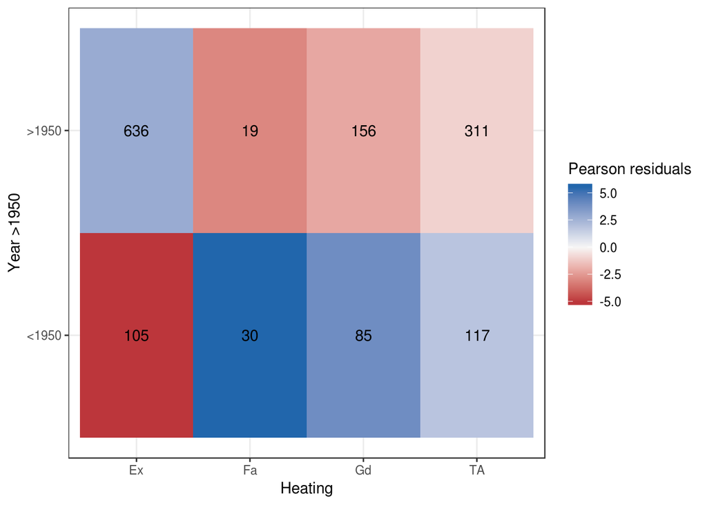

```r
ggplot() +
  geom_raster(data = df_resid, aes(x = housing2.HeatingQC, y = housing2.year1950, fill = Freq), hjust = 0.5, vjust = 0.5) +
  scale_fill_gradient2("Pearson residuals", low = "#b2182b", mid = "#f7f7f7", high = "#2166ac", midpoint = 0) +
  geom_text(data = df_count, aes(x = housing2.HeatingQC, y = housing2.year1950, label = Freq)) +
  xlab("Heating") +
  ylab("Year >1950") +
  theme_bw()
```

Выводы?

## Ваша очередь

Выявите, есть ли следующие взаимосвязи

- Цена жилья и состояние жилья: хорошее vs плохое. Хорошим состоянием считаем параметр `OverallCond` больше 5 (т.е. 10: Very Excellent, 9: Excellent, 8: Very Good, 7: Good, 6: Above Average – см. описание)
- Наличие гаража и состояние жилья
- Цена жилья и район (Район OldTown vs Edwards)
- Район и год постройки ранее 1970 (параметр `YearBuilt`)
- Цена жилья и год постройки ранее 1970 (параметр `YearBuilt`)
- Наличие центральной вентиляции и цена жилья (`CentralAir`)
- Наличие центральной вентиляции и год постройки ранее 1970 (`CentralAir`)
- Наличие гаража и цена жилья
- … Ваши варианты вопросов

## Дополнительные задания

Загрузите базу по колледжам

```r
colleges = ISLR::College
?ISLR::College
```

Ответьте на вопросы, используя подходящие тесты. Обратите внимание, что для ответа на некоторые вопросы недостаточно исходных переменных, а нужно их преобразовать (посчитать доли, разделить на группы и т.д.)

- Есть ли взаимосвязь между числом подаваемых в колледж заявлений и его типом (частный - государственный)
- Отличаются ли частные и государственные колледжи по доле принятых заявлений
- Есть ли взаимосвязь между тем, что доля принятых заявлений составляет более 75%, и типом колледжа
- Есть ли взаимосвязь между числом студентов-бакалавров (F.Undergrad + P.Undergrad) и типом колледжа
- Отличаются ли частные и государственные колледжи по числу выпускников, оказывающих помощь (perc.alumni)
- Есть ли взаимосвязь между тем, что доля окончивших колледж (Grad.Rate) составляет более 50%, и его типом
- Есть ли взаимосвязь между тем, что на одного сотрудника приходится больше 15 студентов (S.F.Ratio), и типом колледжа
- Есть ли взаимосвязь между уровнем расходов на книги (Books) и типом колледжа
- Есть ли взаимосвязь между тем, что доля сотрудников с PhD составляет более 75%, и типом колледжа
- Разделите колледжи на 4 группы по доле принятых заявлений: 1) менее 65%, 2) от 65% до 75%, 3) от 75% до 85%, 4) более 85%. Есть ли взаимосвязь между принадлежностью к группе и типом колледжа
- … Ваши варианты вопросов